# Project 2

# Information about the dataset:

The World Cup Matches dataset contains information about various football (soccer) matches contested as part of the FIFA World Cup tournaments. The dataset includes details such as the year of the tournament, date and time of the match, stage of the tournament, stadium and city where the match took place, names of the home and away teams, goals scored by each team, win conditions, attendance, half-time goals, referee information, and other relevant details.

# Relevance and Key Learning Aspects:

1. Historical Analysis: The dataset allows for a historical analysis of World Cup matches, spanning different years and tournaments. One can explore trends, changes in match dynamics, and team performances over time.
2. Performance Metrics: Examining goals scored by teams provides insights into team performance. Analysis of average goals per match, top-scoring teams, and variation in goals across different stages can reveal patterns and strategies.
3. Tournament Dynamics: Understanding the structure of the tournament stages (group stage, knockout stage) and analyzing performance variations during these stages contributes to a deeper understanding of the dynamics of the World Cup.
4. Attendance Trends: Exploring attendance figures can shed light on the popularity of matches and how it has evolved over the years. Factors influencing attendance, such as host cities and stadiums, can be investigated.
5. Referee Analysis: Examining referee-related data, such as the number of matches officiated by top referees, can provide insights into the role of officiating in World Cup tournaments.
6. Home Advantage: Analyzing matches played by teams on their home ground can reveal whether there is a significant home advantage in the World Cup
7. City and Stadium Analysis: Identifying cities and stadiums that have hosted the most matches can offer insights into the geographical distribution of World Cup events and the significance of specific venues.

By leveraging the Pandas library in Python, the project can explore these aspects through data analysis, visualization, and storytelling, providing a comprehensive view of the World Cup Matches dataset.

# Importing the dataset as pandas data frame, and important libraries:

```python
import pandas as pd
import matplotlib.pyplot as plt
world_cup_matches = pd.read_csv('WorldCupMatches.csv')
```

# The user queries are:

1. What is the average number of goals scored per match in the World Cup?
2. How does attendance vary across different stages of the tournament?
3. Which team has the highest average goals per match in World Cup history? Who makes up the top 10?
4. How has the average attendance changed over the years in the World Cup?
5. Who are the top referees based on the number of matches officiated?
6. Analyze the performance of teams playing on their home ground. Is there a significant home advantage in the World Cup?
7. Which city and stadium have hosted the most World Cup matches? Rank the 10 most frequent?
8. How do the number of goals scored vary in different stages of the tournament (group stage, knockout stage)?

# Implementation of the user queries

## 1. What is the average number of goals scored per match in the World Cup?

```python
average_goals_per_match = world_cup_matches[['Home Team Goals', 'Away Team Goals']].mean(axis=1)
average_goals_per_match_mean = average_goals_per_match.mean()

print(f"The average number of goals scored per match in the World Cup is: {average_goals_per_match_mean:.2f}")
```

```
The average number of goals scored per match in the World Cup is: 1.42
```

## 2. How does attendance vary across different stages of the tournament?

```python
attendance_by_stage = world_cup_matches.groupby('Stage')['Attendance'].mean()
print("Average Attendance Across Different Stages:")
print(attendance_by_stage)
```

```
Average Attendance Across Different Stages:
Stage
Final                       76383.650000
First round                 16120.333333
Group 1                     41664.064516
Group 2                     34241.762712
Group 3                     34271.410714
Group 4                     25915.745455
Group 5                     35354.000000
Group 6                     65658.583333
Group A                     54321.350000
Group B                     51367.866667
Group C                     45514.937500
Group D                     45427.333333
Group E                     45675.916667
Group F                     42840.875000
Group G                     48533.166667
Group H                     46747.033333
Match for third place       50847.866667
Play-off for third place    68034.000000
Preliminary round           16875.000000
Quarter-finals              45697.484848
Round of 16                 52346.842857
Semi-finals                 59053.333333
Third place                 57741.500000
Name: Attendance, dtype: float64
```

### Explanation of result:

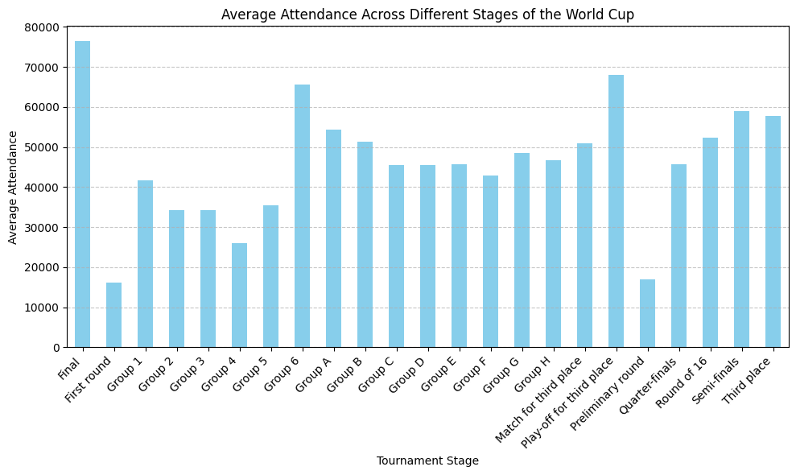

```python
plt.figure(figsize=(10, 6))
attendance_by_stage.plot(kind='bar', color='skyblue')
plt.title('Average Attendance Across Different Stages of the World Cup')
plt.xlabel('Tournament Stage')
plt.ylabel('Average Attendance')
plt.xticks(rotation=45, ha='right')
plt.grid(axis='y', linestyle='--', alpha=0.7)

plt.tight_layout()
plt.show()
```

## 3. Which team has the highest average goals per match in World Cup history? Who makes up the top 10?

```python
goals_by_team = world_cup_matches.groupby('Home Team Name')['Home Team Goals'].mean().add(world_cup_matches.groupby('Away Team Name')['Away Team Goals'].mean())
team_with_highest_average_goals = goals_by_team.idxmax()
highest_average_goals = goals_by_team.max()
print(f"The team with the highest average goals per match in World Cup history is {team_with_highest_average_goals} with an average of {highest_average_goals:.2f} goals per match.")
```

```
The team with the highest average goals per match in World Cup history is Turkey with an average of 6.25 goals per match.
```

### Explanation of result:

```python
top_10_teams = goals_by_team.nlargest(10)
print("Top 10 Teams with the Highest Average Goals per Match in World Cup History:")
print(top_10_teams)
```

[output not shown]

### Explanation of code:

1. top_10_teams = goals_by_team.nlargest(10): This line identifies the top 10 teams with the highest average goals per match using the nlargest function.

### Explanation of result:

A lists the top 10 teams along with their average goals per match.

## 4. How has the average attendance changed over the years in the World Cup?

```python
average_attendance_by_year = world_cup_matches.groupby('Year')['Attendance'].mean()
print("Average Attendance Across Different Years:")
print(average_attendance_by_year)
```

```
Average Attendance Across Different Years:
Year
1930.0    32808.277778
1934.0    21352.941176
1938.0    20872.222222
1950.0    47511.181818
1954.0    29561.807692
1958.0    23423.142857
1962.0    27911.625000
1966.0    48847.968750
1970.0    50124.218750
1974.0    49098.763158
1978.0    40678.710526
1982.0    40571.596154
1986.0    46039.057692
1990.0    48388.750000
1994.0    68991.115385
1998.0    43517.187500
2002.0    42268.703125
2006.0    52491.234375
2010.0    49669.625000
2014.0    55374.910256
Name: Attendance, dtype: float64
```

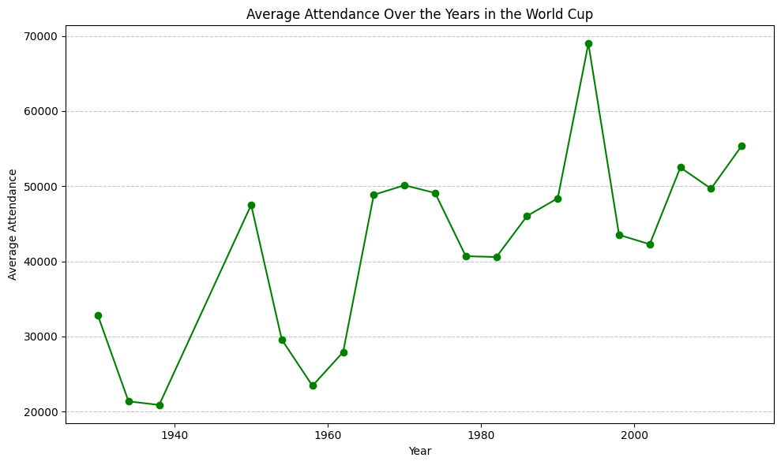

```python
plt.figure(figsize=(10, 6))
average_attendance_by_year.plot(kind='line', marker='o', color='green')
plt.title('Average Attendance Over the Years in the World Cup')
plt.xlabel('Year')
plt.ylabel('Average Attendance')
plt.grid(axis='y', linestyle='--', alpha=0.7)

plt.tight_layout()
plt.show()
```

### Explanation of code:

1. world_cup_matches.groupby('Year'): This groups the DataFrame by the 'Year' column, creating subsets of data for each unique year in the World Cup.
2. ['Attendance'].mean(): This selects the 'Attendance' column from each subset and calculates the mean (average) attendance for each year based on the grouped data.
3. The result is a Pandas Series where each year is the index, and the corresponding value is the average attendance for that year.

### Explanation of result:

The output shows the average attendance across different years in the World Cup. For example, in the year 1930, the average attendance was 32,808.28, and so on for subsequent years. This information provides insights into how attendance has changed over the years in the history of the World Cup tournament. Which is useful in seeing how the World Cup Has grown over the years.

## 5. Who are the top referees based on the number of matches officiated?

```python
matches_per_referee = pd.concat([world_cup_matches['Referee'], world_cup_matches['Assistant 1'], world_cup_matches['Assistant 2']], axis=0)
matches_per_referee_count = matches_per_referee.value_counts()

top_referees = matches_per_referee_count.head(10)
print("Top 10 Referees Based on Number of Matches Officiated:")
print(top_referees)
```

```
Top 10 Referees Based on Number of Matches Officiated:
VERGARA Hector (CAN)        14
GARDEAZABAL Juan (ESP)      13
ELLIS Arthur (ENG)          13
RAINEA Nicolae (ROU)        13
DAVIDSON Bob (SCO)          12
PALOTAI Karoly (HUN)        12
GRIFFITHS Benjamin (WAL)    12
AL SHARIF Jamal (SYR)       12
QUINIOU Joel (FRA)          12
ZSOLT Istvan (HUN)          12
Name: count, dtype: int64
```

### Explanation of code:

1. pd.concat([world_cup_matches['Referee'], world_cup_matches['Assistant 1'], world_cup_matches['Assistant 2']], axis=0): This concatenates the 'Referee', 'Assistant 1', and 'Assistant 2' columns along axis 0, creating a series of all match officials.
2. .value_counts(): This counts the occurrences of each unique match official in the concatenated series, representing the number of matches officiated by each official.
3. matches_per_referee_count.head(10): This selects the top 10 match officials based on the count of matches officiated

### Explanation of result:

The output shows the top 10 referees and the number of matches each referee officiated in the World Cup. For example, VERGARA Hector (CAN) officiated in 14 matches, GARDEAZABAL Juan (ESP) in 13 matches, and so on. This information provides insights into the most experienced and frequently used referees in the history of the World Cup tournament.

## 6. Analyze the performance of teams playing on their home ground. Is there a significant home advantage in the World Cup?

```python
world_cup_matches['Home Team Win'] = world_cup_matches['Home Team Goals'] > world_cup_matches['Away Team Goals']
home_team_win_percentage = world_cup_matches['Home Team Win'].mean() * 100

print(f"The percentage of matches won by the home team in the World Cup is: {home_team_win_percentage:.2f}%")
```

```
The percentage of matches won by the home team in the World Cup is: 10.67%
```

### Explanation of code:

1. world_cup_matches['Home Team Win'] = world_cup_matches['Home Team Goals'] > world_cup_matches['Away Team Goals']: This line creates a new column named 'Home Team Win', which is a boolean column indicating whether the home team won the match. It compares the number of goals scored by the home team with the number of goals scored by the away team.
2. world_cup_matches['Home Team Win'].mean(): This calculates the mean (average) of the 'Home Team Win' column, which represents the percentage of matches won by the home team.
3. - 100: This multiplies the mean by 100 to convert it into a percentage

### Explanation of result:

The output, "The percentage of matches won by the home team in the World Cup is: 10.67%", indicates that, on average, the home team has won approximately 10.67% of the matches in the World Cup based on the provided dataset. This information suggests a relatively low home advantage in terms of match outcomes in the World Cup.

## 7. Which city and stadium have hosted the most World Cup matches? Rank the 10 most frequent?

```python
matches_per_city = world_cup_matches['City'].value_counts()
matches_per_stadium = world_cup_matches['Stadium'].value_counts()

most_hosted_city = matches_per_city.idxmax()
most_hosted_stadium = matches_per_stadium.idxmax()

print(f"The city that has hosted the most World Cup matches is: {most_hosted_city}")
print(f"The stadium that has hosted the most World Cup matches is: {most_hosted_stadium}")
```

```
The city that has hosted the most World Cup matches is: Mexico City
The stadium that has hosted the most World Cup matches is: Estadio Azteca
```

### Explanation of code:

1. matches_per_city = world_cup_matches['City'].value_counts(): This line counts the number of matches hosted in each city using the 'City' column and the value_counts() function.
2. matches_per_stadium = world_cup_matches['Stadium'].value_counts(): This line counts the number of matches hosted in each stadium using the 'Stadium' column and the value_counts() function.
3. most_hosted_city = matches_per_city.idxmax(): This line finds the city that has hosted the most matches using the idxmax() function, which returns the index (city name) corresponding to the maximum value.
4. most_hosted_stadium = matches_per_stadium.idxmax(): This line finds the stadium that has hosted the most matches using the idxmax() function.

### Explanation of result:

```python
top_10_cities = matches_per_city.nlargest(10)

print("Top 10 Cities that Hosted the Most World Cup Matches:")
print(top_10_cities)
```

```
Top 10 Cities that Hosted the Most World Cup Matches:
City
Mexico City        23
Montevideo         18
Rio De Janeiro     18
Guadalajara        17
Johannesburg       15
Sao Paulo          14
Buenos Aires       12
Munich             11
Leon               11
Belo Horizonte     11
Name: count, dtype: int64
```

### Explanation of code:

1. top_10_cities = matches_per_city.nlargest(10): This line identifies the top 10 cities that hosted the most matches using the nlargest function.

### Explanation of result:

A list of the top 10 cities and stadiums based on the number of World Cup matches hosted.

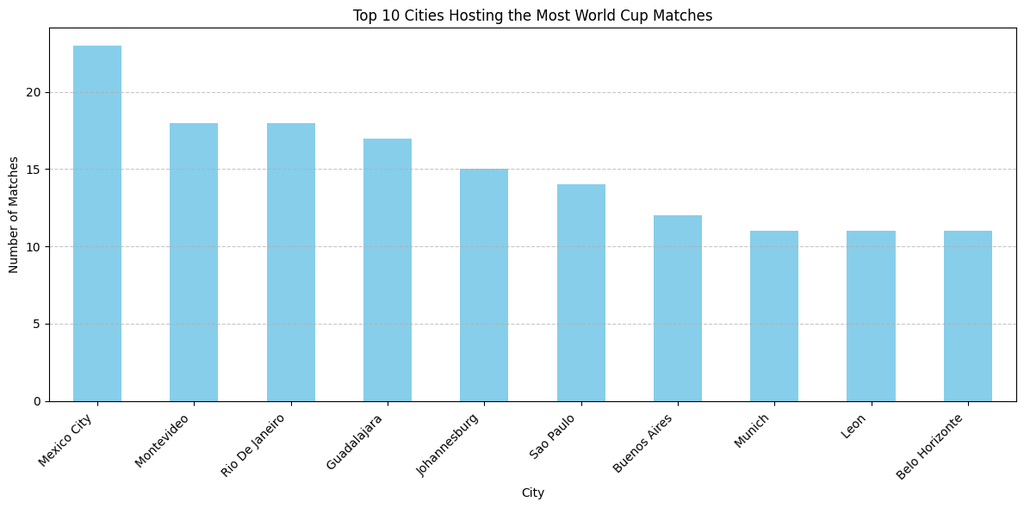

```python
plt.figure(figsize=(12, 6))
top_10_cities.plot(kind='bar', color='skyblue')
plt.title('Top 10 Cities Hosting the Most World Cup Matches')
plt.xlabel('City')
plt.ylabel('Number of Matches')
plt.xticks(rotation=45, ha='right')
plt.grid(axis='y', linestyle='--', alpha=0.7)

plt.tight_layout()
plt.show()
```

```python
top_10_stadiums = matches_per_stadium.nlargest(10)

print("\nTop 10 Stadiums that Hosted the Most World Cup Matches:")
print(top_10_stadiums)
```

```
Top 10 Stadiums that Hosted the Most World Cup Matches:
Stadium
Estadio Azteca             19
Jalisco                    14
Olympiastadion             14
Nou Camp - Estadio Le�n    11
Estadio Centenario         10
Estadio do Maracana        10
Estadio Nacional           10
Nacional                   10
Wembley Stadium             9
Stade du Parc Lescure       9
Name: count, dtype: int64
```

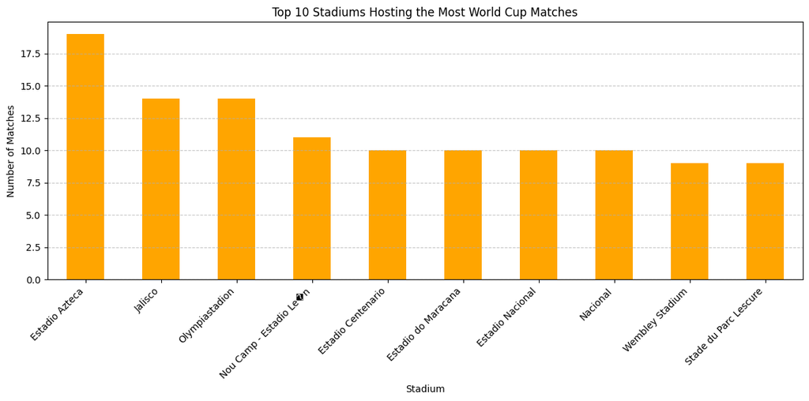

```python
plt.figure(figsize=(12, 6))
top_10_stadiums.plot(kind='bar', color='orange')
plt.title('Top 10 Stadiums Hosting the Most World Cup Matches')
plt.xlabel('Stadium')
plt.ylabel('Number of Matches')
plt.xticks(rotation=45, ha='right')
plt.grid(axis='y', linestyle='--', alpha=0.7)

plt.tight_layout()
plt.show()
```

## 8. How do the number of goals scored vary in different stages of the tournament (group stage, knockout stage)?

```python
world_cup_matches['Tournament Stage'] = world_cup_matches['Stage'].apply(lambda x: 'Group Stage' if pd.notna(x) and 'Group' in x else 'Knockout Stage')
goals_by_stage = world_cup_matches.groupby('Tournament Stage')[['Home Team Goals', 'Away Team Goals']].sum()
print("Goals in different stages of the tournament (group stage, knockout stage):")
print(goals_by_stage)
```

```
Goals in different stages of the tournament (group stage, knockout stage):
                  Home Team Goals  Away Team Goals
Tournament Stage
Group Stage                1089.0            602.0
Knockout Stage              454.0            269.0
```

### Explanation of code:

1. world_cup_matches['Tournament Stage'] = world_cup_matches['Stage'].apply(lambda x: 'Group Stage' if pd.notna(x) and 'Group' in x else 'Knockout Stage'): This line creates a new column 'Tournament Stage' based on the 'Stage' column. If the stage contains 'Group,' it is labeled as 'Group Stage'; otherwise, it is labeled as 'Knockout Stage'.
2. world_cup_matches.groupby('Tournament Stage')[['Home Team Goals', 'Away Team Goals']].sum(): This line groups the data by the 'Tournament Stage' column and calculates the sum of home team goals and away team goals for each stage using the sum() function.

### Explanation of result:

The output shows the total number of home team and away team goals scored in the 'Group Stage' and 'Knockout Stage.' For example, in the 'Group Stage,' there were 1089 home team goals and 602 away team goals, while in the 'Knockout Stage,' there were 454 home team goals and 269 away team goals. This information provides insights into how goal-scoring varies between the group and knockout stages of the World Cup tournament.

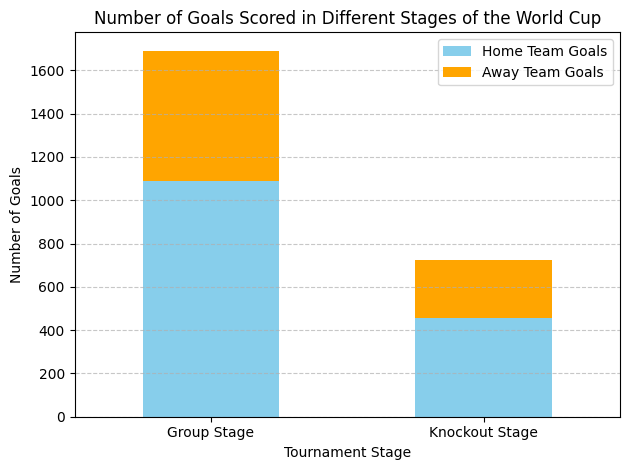

```python
plt.figure(figsize=(10, 6))
goals_by_stage.plot(kind='bar', stacked=True, color=['skyblue', 'orange'])
plt.title('Number of Goals Scored in Different Stages of the World Cup')
plt.xlabel('Tournament Stage')
plt.ylabel('Number of Goals')
plt.xticks(rotation=0)
plt.legend(['Home Team Goals', 'Away Team Goals'])
plt.grid(axis='y', linestyle='--', alpha=0.7)

# Show the plot
plt.tight_layout()
plt.show()
```